# Binomial Distribution

Jeonghyeon Dang

2019-05-03

## Binomial Distribution

The package `"binomial"` is a minimal implementation for calculating probabilities of a Binomial random variable, and related calculations such as the probability distribution, the expected value, variance.

## Function bin_choose()

Function bin_choose() that calculates the number of combinations in which k successes can occur in n trials.

```r
library(binomial)

bin_choose(n = 5, k = 2)
```

```
## [1] 10
```

```r
bin_choose(5, 0)
```

```
## [1] 1
```

```r
bin_choose(5, 1:3)
```

```
## [1]  5 10 10
```

## Function bin_probability()

Function bin_probability() that calculates the probability of getting k successes in n trials with specific probability of success.

```r
# probability of getting 2 successes in 5 trials
# (assuming prob of success = 0.5)
bin_probability(success = 2, trials = 5, prob = 0.5)
```

```
## [1] 0.3125
```

```r
# probabilities of getting 2 or less successes in 5 trials
# (assuming prob of success = 0.5)
bin_probability(success = 0:2, trials = 5, prob = 0.5)
```

```
## [1] 0.03125 0.15625 0.31250
```

```r
# 55 heads in 100 tosses of a loaded coin with 45% chance of heads
bin_probability(success = 55, trials = 100, prob = 0.45)
```

```
## [1] 0.01075277
```

## Function bin_distribution()

Function bin_distribution() that returns a data frame with the probability distribution: sucesses in the first column, probability in the second column.

```r
# binomial probability distribution
bin_distribution(trials = 5, prob = 0.5)
```

```
##   success probability
## 1       0     0.03125
## 2       1     0.15625
## 3       2     0.31250
## 4       3     0.31250
## 5       4     0.15625
## 6       5     0.03125
```

### Function plot.bindis()

plot.bindis() that graphs a barplot to display the probability histogram of a binomial distribution object “bindis”.

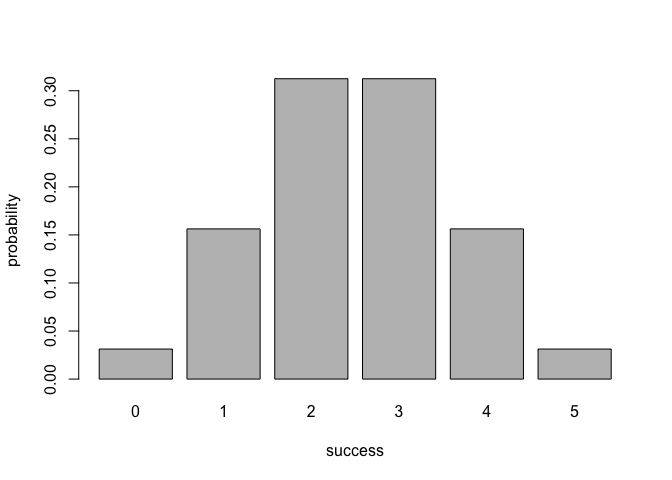

```r
# plotting binomial probability distribution
dis1 <- bin_distribution(trials = 5, prob = 0.5)
plot(dis1)
```

## Function bin_cumulative()

Function bin_cumulative() that returns a data frame with both the probability distribution and the cumulative probabilities: sucesses in the first column, probability in the second column, and cumulative in the third column.

```r
# binomial cumulative distribution
bin_cumulative(trials = 5, prob = 0.5)
```

```
##   success probability cumulative
## 1       0     0.03125    0.03125
## 2       1     0.15625    0.18750
## 3       2     0.31250    0.50000
## 4       3     0.31250    0.81250
## 5       4     0.15625    0.96875
## 6       5     0.03125    1.00000
```

### Function plot.bincum()

plot.bincum() that graphs the cumulative distribution in ab object “bincum”.

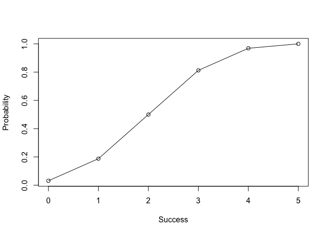

```r
# plotting binomial cumulative distribution
dis2 <- bin_cumulative(trials = 5, prob = 0.5)
plot(dis2)
```

## Function bin_variable()

Function bin_variable() returns an object of class “binvar”, that is, a binomial random variable object.

### Method print.binvar()

Method function print.binvar() to be able to nicely print the content of an object “binvar”.

```r
bin1 <- bin_variable(trials = 10, p = 0.3)
bin1
```

```
## "Binomial variable"
##
## Parameters
## - number of trials: 10
## - prob of success: 0.3
```

### Methods summary.binvar() and print.summary.binvar()

Methods summary.binvar() returns a list of class “summary.binvar” containing named elements:

- – trials: number of trials
- – prob: probability of success
- – mean: mean or expected value
- – variance: variance
- – mode: mode
- – skewness: skewness
- – kurtosis: kurtosis

Methods print.summary.binvar() to nicely print the contents of an object “summary.binvar”.

```r
binsum1 <- summary(bin1)
binsum1
```

```
## "Summary Binomial"
##
## Parameters
## - number of trials: 10
## - prob of success: 0.3
##
## Measures
## - mean    : 3
## - variance: 2.1
## - mode    : 3
## - skewness: 0.2760262
## - kurtosis: -0.1238095
```